# PISA 2012 - Data Analysis

## PISA 2012 Dataset Overview

PISA is the OECD's Programme for International Student Assessment. Every three years it tests 15 year old students from all over the world in Reading, Mathematics and Science. The tests are designed to gauge how well the students master key subjects in order to be prepared for real-life situations in the adult world. This is not a conventional school test. Rather than examining how well students have learned the school curriculum, it looks at how well prepared they are for life beyond school.

Our data comprises of 485,490 students from 65 economies who took part in the PISA 2012 assessment of Reading, Mathematics and Science representing about 31.5 million 15-year-olds globally.

## Investigation Overview

1) Top 15 Countries of the world who appeared for PISA 2012 test in terms of Student Strength and Gender.  
2) Average Subject Score Distribution of Students.  
3) Top Performing Countries of PISA 2012.  
4) Impact of Parent Origin Country on Student Performance.  
5) Gender wise distribution of Average Subject scores and Top performers worldwide.

```python
#Importing the necessary libraries
import numpy as np
import pandas as pd
import matplotlib.pyplot as plt
import seaborn as sb

%matplotlib inline

# suppress warnings from final output
import warnings
warnings.simplefilter("ignore")
```

```python
# load in the dataset into a pandas dataframe
pisa= pd.read_csv('pisa_clean.csv')
```

## Visualization 1: Country wise distribution of PISA 2012 students

- Mexico is topping the list with the maximum number of students appearing for PISA 2012, followed closely by Italy and then by Spain, Canada and Brazil.

```python
country_count= pisa.Country.value_counts().head(15)
base_color= sb.color_palette()[0]
```

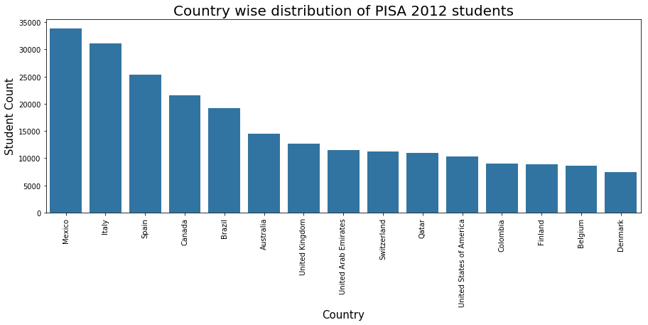

```python
# Country wise distribution of PISA 2012 students
plt.figure(figsize=(15,5))
sb.countplot(data= pisa, x= 'Country', color=base_color, order= country_count.index)
plt.xlabel('Country',fontsize= 15)
plt.ylabel('Student Count',fontsize= 15)
plt.xticks(rotation=90)
plt.title('Country wise distribution of PISA 2012 students',fontsize= 20);
```

## Visualization 2: Average Score Distribution across Students

- The maximum number of students score between the range of 400-500 in all the three subjects followed by the second maximum number of students scoring between the 500-600 range.
- The highest scores of 700 and above are scored by only very few students.

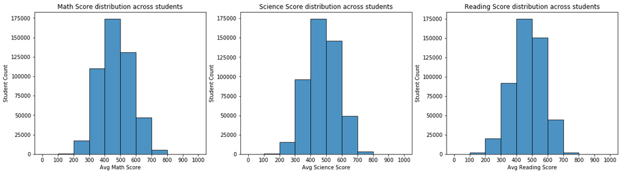

```python
bins_scores= np.arange(0,950+100,100)

plt.figure(figsize = [20, 5])
#Let us plot our histograms
plt.subplot(1, 3, 1)
plt.hist(pisa['Avg Math Score'], bins = bins_scores, ec = 'black', alpha = 0.8);

plt.xticks(bins_scores)
plt.xlabel('Avg Math Score');
plt.ylabel('Student Count')
plt.title("Math Score distribution across students");


plt.subplot(1, 3, 2)
plt.hist(pisa['Avg Science Score'], bins = bins_scores, ec = 'black', alpha = 0.8);

plt.xticks(bins_scores)
plt.xlabel('Avg Science Score');
plt.ylabel('Student Count')
plt.title("Science Score distribution across students");


plt.subplot(1, 3, 3)
plt.hist(pisa['Avg Reading Score'], bins = bins_scores, ec = 'black', alpha = 0.8);

plt.xticks(bins_scores)
plt.xlabel('Avg Reading Score');
plt.ylabel('Student Count')
plt.title("Reading Score distribution across students");
```

## Visualization 3: Top performing countries of PISA 2012

- China-Shanghai is home to the highest Math scorers in the world at PISA 2012, followed by Chinese Taipei, Singapore and Korea thereby highlighting the East-Asian talent.
- Singapore is the Top Performing Country in Science followed by and Australia.
- Singapore again has bagged the Top Performing Country in Reading; this time it's followed by Japan.

```python
# Let us segregate the PISA students who scored above 800 and get their respective Countries for the three subjects
high_math_score= pisa[pisa['Avg Math Score']>800]['Country'].value_counts()
high_science_score= pisa[pisa['Avg Science Score']>800]['Country'].value_counts()
high_reading_score= pisa[pisa['Avg Reading Score']>800]['Country'].value_counts()
```

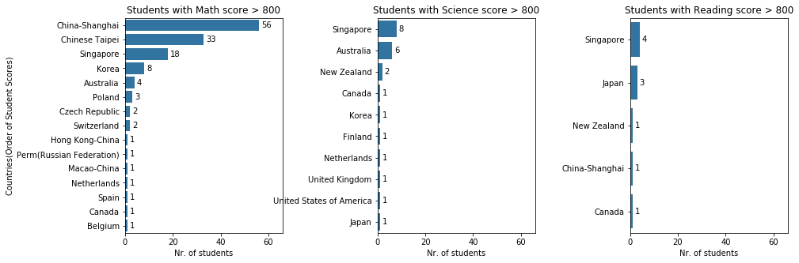

```python
# Let us plot the Countries vs Student Count whose average subject scores are greater than 800.
plt.figure(figsize = [15, 5])
plt.subplots_adjust(wspace= 0.6)
x_limit= max(high_math_score)+10

plt.subplot(1,3,1)
sb.barplot(x= high_math_score.values, y=high_math_score.index, color= sb.color_palette()[0])
plt.xlim(0,x_limit)
plt.xlabel('Nr. of students')
plt.ylabel('Countries(Order of Student Scores)')
plt.title('Students with Math score > 800');

indexes, labels = plt.yticks()
for index, label in zip(indexes, labels):
    plt.text(y = index, x = high_math_score[label.get_text()] + 1, s = high_math_score[label.get_text()], va = 'center');


plt.subplot(1,3,2)
sb.barplot(x= high_science_score.values, y=high_science_score.index, color= sb.color_palette()[0])
plt.xlim(0,x_limit)
plt.xlabel('Nr. of students')
plt.title('Students with Science score > 800');
indexes, labels = plt.yticks()
for index, label in zip(indexes, labels):
    plt.text(y = index, x = high_science_score[label.get_text()] + 1, s = high_science_score[label.get_text()], va = 'center');


plt.subplot(1,3,3)
sb.barplot(x= high_reading_score.values, y=high_reading_score.index, color= sb.color_palette()[0])
plt.xlim(0,x_limit)
plt.xlabel('Nr. of students')
plt.title('Students with Reading score > 800');
indexes, labels = plt.yticks()
for index, label in zip(indexes, labels):
    plt.text(y = index, x = high_reading_score[label.get_text()] + 1, s = high_reading_score[label.get_text()], va = 'center');
```

## Visualization 4: Gender wise distinction of Top 15 Countries of the world in PISA 2012 test

- Mexico, with the maximum number of students, is clearly seen to have more Girls appearing for the test compared to Boys.
- Canada, Brazil and Columbia have a higher Female to Male ratio while Italy, Australia and Qatar have lower Female to Male ratio.

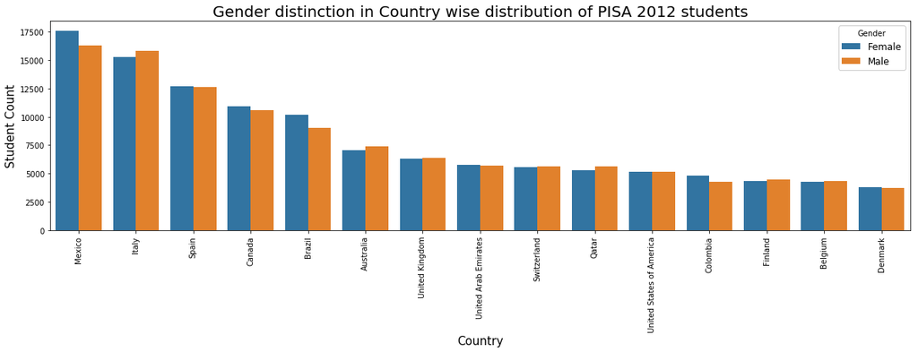

```python
plt.figure(figsize=(20,5))
ax = sb.countplot(data = pisa, x = 'Country', hue = 'Gender', order= country_count.head(15).index)
ax.legend(loc = 'best', framealpha = 1, title = 'Gender', fontsize=12);
plt.xlabel('Country',fontsize= 15)
plt.ylabel('Student Count',fontsize= 15)
plt.xticks(rotation=90)
plt.title('Gender distinction in Country wise distribution of PISA 2012 students',fontsize= 20);
```

## Visualization 5: Parent Country Origin vs Average Subject Scores

- Students with Parent Origin from Different countries have scored slightly better in the PISA 2012 test compared to those whose Parent's Origin are from the Same country.

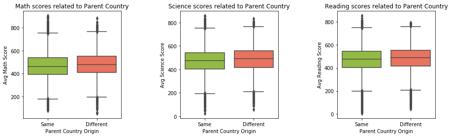

```python
# Parent Country Origin vs Average Subject Scores
plt.figure(figsize = [15, 4])
plt.subplots_adjust(wspace= 0.6)

plt.subplot(1,3,1)
my_pal = {"Same": "yellowgreen", "Different": "tomato"}
sb.boxplot(x= pisa['Parent Country Origin'], y= pisa['Avg Math Score'], palette= my_pal)
plt.title('Math scores related to Parent Country');

plt.subplot(1,3,2)
sb.boxplot(x= pisa['Parent Country Origin'], y= pisa['Avg Science Score'],palette= my_pal)
plt.title('Science scores related to Parent Country');


plt.subplot(1,3,3)
sb.boxplot(x= pisa['Parent Country Origin'], y= pisa['Avg Reading Score'],palette= my_pal)
plt.title('Reading scores related to Parent Country');
```

## Visualization 6: Correlation between all the three subject scores

- The Avg Math Score, Avg Science Score and Avg Reading Score columns show a high positive correlation between each other.

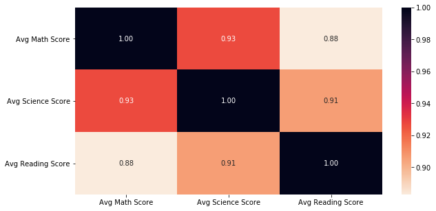

```python
# Let us find the correlation between the three quantitative variables using a heatmap.
plt.figure(figsize=(10,5))
corr_vars= pisa[['Avg Math Score','Avg Science Score','Avg Reading Score']].corr()
sb.heatmap(corr_vars, annot = True, fmt = '.2f', cmap = 'rocket_r');
```

## Visualization 7: Gender wise distribution of Average Subject scores

- Girls score their highest in Reading followed by Science and Math.
- Boys score their highest in both Math and Science while their least scores are in Reading.

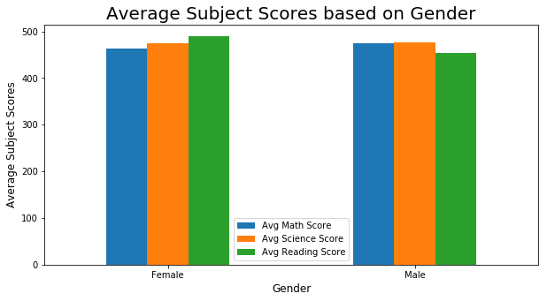

```python
# Here we plot the three quantitative variables of average subject scores vs a categorical gender variable.
plt.rcParams['figure.figsize'] = [10, 5]
Gender_Scores= pisa.groupby(['Gender']).mean()[['Avg Math Score','Avg Science Score','Avg Reading Score']]
Gender_Scores.plot(kind='bar');
plt.xlabel('Gender', fontsize= 12)
plt.ylabel('Average Subject Scores',fontsize= 12)
plt.title('Average Subject Scores based on Gender',fontsize= 20)
plt.xticks(rotation=0)
plt.legend(loc='best');
```

## Visualizations 8: Gender wise distribution of Top Performers Worldwide in PISA 2012 (for three Avg Subject Scores)

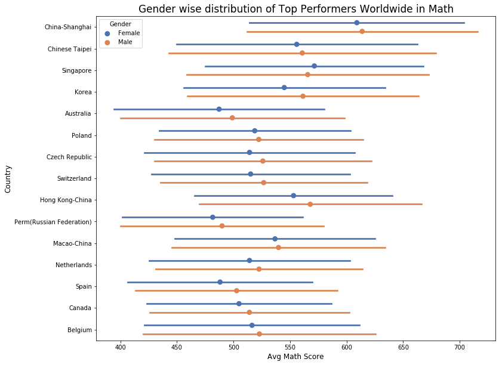

```python
# Gender wise distribution of Top Performers Worldwide in Math
plt.figure(figsize=(12,10))
ax = sb.pointplot(data = pisa, y = 'Country', x = 'Avg Math Score', hue = 'Gender',order= high_math_score.index,
                  dodge = 0.4, ci = 'sd', palette = 'deep', linestyles = "")
plt.xlabel('Avg Math Score',fontsize= 12)
plt.ylabel('Country',fontsize= 12)
plt.title('Gender wise distribution of Top Performers Worldwide in Math', fontsize= 17);
```

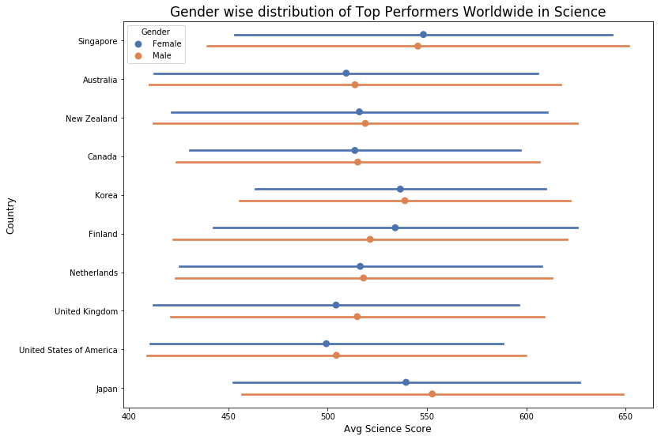

```python
#Gender wise distribution of Top Performers Worldwide in Science
plt.figure(figsize=(12,9))
ax = sb.pointplot(data = pisa, y = 'Country', x = 'Avg Science Score', hue = 'Gender',order= high_science_score.index,
                  dodge = 0.3, ci = 'sd', palette = 'deep', linestyles = "")
plt.xlabel('Avg Science Score',fontsize= 12)
plt.ylabel('Country',fontsize= 12)
plt.title('Gender wise distribution of Top Performers Worldwide in Science', fontsize= 17);
```

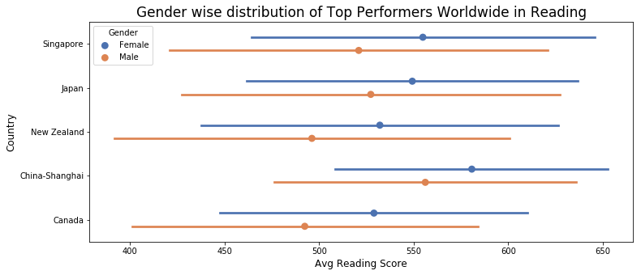

```python
#Gender wise distribution of Top Performers Worldwide in Reading
plt.figure(figsize=(12,5))
ax = sb.pointplot(data = pisa, y = 'Country', x = 'Avg Reading Score', hue = 'Gender',order= high_reading_score.index,
                  dodge = 0.3, ci = 'sd', palette = 'deep', linestyles = "")
plt.xlabel('Avg Reading Score',fontsize= 12)
plt.ylabel('Country',fontsize= 12)
plt.title('Gender wise distribution of Top Performers Worldwide in Reading', fontsize= 17);
```